# Bankruptcy Prediction Dataset

## Description

The dataset is about bankruptcy prediction of Polish companies. The data was collected from Emerging Markets Information Service, which is a database containing information on emerging markets around the world. The bankrupt companies were analyzed in the period 2000-2012, while the still operating companies were evaluated from 2007 to 2013.

Basing on the collected data five classification cases were distinguished, that depends on the forecasting period:

- The data contains financial rates from 1st year of the forecasting period and corresponding class label that indicates bankruptcy status after 5 years. The data contains 7027 instances (financial statements), 271 represents bankrupted companies, 6756 firms that did not bankrupt in the forecasting period.

## Attribute Information

- `Id`: Company Identifier
- `X1`: net profit / total assets
- `X2`: total liabilities / total assets
- `X3`: working capital / total assets
- `X4`: current assets / short-term liabilities
- `X5`: [(cash + short-term securities + receivables - short-term liabilities) / (operating expenses - depreciation)] * 365
- `X6`: retained earnings / total assets
- `X7`: EBIT / total assets
- `X8`: book value of equity / total liabilities
- `X9`: sales / total assets
- `X10`: equity / total assets
- `X11`: (gross profit + extraordinary items + financial expenses) / total assets
- `X12`: gross profit / short-term liabilities
- `X13`: (gross profit + depreciation) / sales
- `X14`: (gross profit + interest) / total assets
- `X15`: (total liabilities * 365) / (gross profit + depreciation)
- `X16`: (gross profit + depreciation) / total liabilities
- `X17`: total assets / total liabilities
- `X18`: gross profit / total assets
- `X19`: gross profit / sales
- `X20`: (inventory * 365) / sales
- `X21`: sales (n) / sales (n-1)
- `X22`: profit on operating activities / total assets
- `X23`: net profit / sales
- `X24`: gross profit (in 3 years) / total assets
- `X25`: (equity - share capital) / total assets
- `X26`: (net profit + depreciation) / total liabilities
- `X27`: profit on operating activities / financial expenses
- `X28`: working capital / fixed assets
- `X29`: logarithm of total assets
- `X30`: (total liabilities - cash) / sales
- `X31`: (gross profit + interest) / sales
- `X32`: (current liabilities * 365) / cost of products sold
- `X33`: operating expenses / short-term liabilities
- `X34`: operating expenses / total liabilities
- `X35`: profit on sales / total assets
- `X36`: total sales / total assets
- `X37`: (current assets - inventories) / long-term liabilities
- `X38`: constant capital / total assets
- `X39`: profit on sales / sales
- `X40`: (current assets - inventory - receivables) / short-term liabilities
- `X41`: total liabilities / ((profit on operating activities + depreciation) * (12/365))
- `X42`: profit on operating activities / sales
- `X43`: rotation receivables + inventory turnover in days
- `X44`: (receivables * 365) / sales
- `X45`: net profit / inventory
- `X46`: (current assets - inventory) / short-term liabilities
- `X47`: (inventory * 365) / cost of products sold
- `X48`: EBITDA (profit on operating activities - depreciation) / total assets
- `X49`: EBITDA (profit on operating activities - depreciation) / sales
- `X50`: current assets / total liabilities
- `X51`: short-term liabilities / total assets
- `X52`: (short-term liabilities * 365) / cost of products sold
- `X53`: equity / fixed assets
- `X54`: constant capital / fixed assets
- `X55`: working capital
- `X56`: (sales - cost of products sold) / sales
- `X57`: (current assets - inventory - short-term liabilities) / (sales - gross profit - depreciation)
- `X58`: total costs / total sales
- `X59`: long-term liabilities / equity
- `X60`: sales / inventory
- `X61`: sales / receivables
- `X62`: (short-term liabilities * 365) / sales
- `X63`: sales / short-term liabilities
- `X64`: sales / fixed assets

## Class Values for Binary Classification

- `0`: Company that did not bankrupt after 5 years
- `1`: Bankrupted company

```python
import pandas as pd
import numpy as np
import matplotlib.pyplot as plt
import seaborn as sns
import missingno as msno
import warnings
warnings.filterwarnings("ignore")
import scipy.stats as stats
import math
from scipy.io import arff
from sklearn.model_selection import GridSearchCV, train_test_split
from sklearn.preprocessing import StandardScaler
from scipy.stats import shapiro
from imblearn.over_sampling import SMOTE
from sklearn.linear_model import  LogisticRegression, Lasso
from sklearn.metrics import classification_report, accuracy_score, precision_score, recall_score, f1_score, roc_curve, auc
from sklearn.impute import SimpleImputer

import chart_studio.plotly as py
import cufflinks as cf
from plotly.offline import download_plotlyjs, init_notebook_mode, iplot
init_notebook_mode(connected=True)
cf.go_offline()
import chart_studio.plotly as py
from plotly.offline import download_plotlyjs, init_notebook_mode, iplot
from sklearn.model_selection import train_test_split
from ipywidgets import interact, Dropdown
#to display all the attributes
pd.set_option('display.max_columns', None)
pd.set_option('display.max_rows', None)
```

# READING FILE

In this section, We have read our file and replaced ? by nan.

```python
# Load data from an ARFF file and convert it to a DataFrame
data=arff.loadarff("C:/Users/shiva/Desktop/Bankruptcy/1year.arff")
df=pd.DataFrame(data[0])
```

# UNDERSTANDING DATA

```python
#shape
df.shape
```

```
(7027, 65)
```

```python
#counts
df['class'].value_counts()
```

```
class
b'0'    6756
b'1'     271
Name: count, dtype: int64
```

```python
df.sample(5)
```

|  | Attr1 | Attr2 | Attr3 | Attr4 | Attr5 | Attr6 | Attr7 | Attr8 | Attr9 | Attr10 | Attr11 | Attr12 | Attr13 | Attr14 | Attr15 | Attr16 | Attr17 | Attr18 | Attr19 | Attr20 | Attr21 | Attr22 | Attr23 | Attr24 | Attr25 | Attr26 | Attr27 | Attr28 | Attr29 | … |
| --- | --- | --- | --- | --- | --- | --- | --- | --- | --- | --- | --- | --- | --- | --- | --- | --- | --- | --- | --- | --- | --- | --- | --- | --- | --- | --- | --- | --- | --- | --- |
| 2434 | 0.000000 | 0.00000 | 0.000000 | NaN | -0.27855 | 0.000000 | 15.822000 | NaN | 183.86000 | 99.70200 | 15.822000 | NaN | 0.630310 | 15.822000 | 0.0 | NaN | NaN | 15.822000 | 0.086051 | 156.990 | NaN | 0.000000 | 0.000000 | 15.822000 | 34.64200 | NaN | NaN | 0.00000 | 1.9017 | … |
| 992 | 0.064240 | 0.68667 | 0.241980 | 1.35240 | -77.56800 | 0.174640 | 0.081762 | 0.451970 | 1.02460 | 0.31035 | 0.081762 | 0.11907 | 0.043126 | 0.081762 | 2322.4 | 0.157160 | 1.4563 | 0.081762 | 0.032674 | 110.380 | 1.05140 | 0.090200 | 0.025671 | 0.222520 | 0.31035 | 0.131650 | 0.36933 | 3.39100 | 4.2945 | … |
| 4160 | 0.049264 | 0.93159 | -0.176080 | 0.69712 | -90.83000 | 0.050722 | 0.062306 | 0.068087 | 1.04810 | 0.06343 | 0.062306 | 0.10717 | 0.047607 | 0.062306 | 4702.7 | 0.077615 | 1.0734 | 0.062306 | 0.041023 | 44.657 | 1.29660 | 0.072362 | 0.032436 | 0.065288 | 0.06343 | 0.063615 | 0.49938 | -0.29607 | 4.4774 | … |
| 6557 | 0.071507 | 0.71141 | 0.050685 | 1.07140 | -59.03800 | 0.139600 | 0.085801 | 0.393270 | 1.03530 | 0.27978 | 0.085801 | 0.12081 | 0.036345 | 0.085801 | 2697.1 | 0.135330 | 1.4057 | 0.085801 | 0.032391 | 59.808 | 1.14990 | 0.103600 | 0.026995 | 0.175840 | 0.27978 | 0.115240 | 0.40488 | 0.21196 | 4.9079 | … |
| 2498 | 0.033343 | 0.40637 | 0.024917 | 1.06260 | -43.01100 | 0.067157 | 0.045193 | 1.168300 | 0.96864 | 0.47476 | 0.045193 | 0.11358 | 0.069071 | 0.045193 | 1535.3 | 0.237730 | 2.4608 | 0.045193 | 0.032311 | 49.096 | 0.88635 | 0.057210 | 0.023840 | 0.105230 | 0.47476 | 0.208570 | 0.39621 | 0.04317 | 3.9842 | … |

```python
#to see overall structure of data and to know if there are missing values
df.info()
```

```
<class 'pandas.core.frame.DataFrame'>
RangeIndex: 7027 entries, 0 to 7026
Data columns (total 65 columns):
 #   Column  Non-Null Count  Dtype
---  ------  --------------  -----
 0   Attr1   7024 non-null   float64
 1   Attr2   7024 non-null   float64
 2   Attr3   7024 non-null   float64
 3   Attr4   6997 non-null   float64
 4   Attr5   7019 non-null   float64
 5   Attr6   7024 non-null   float64
 6   Attr7   7024 non-null   float64
 7   Attr8   7002 non-null   float64
 8   Attr9   7026 non-null   float64
 9   Attr10  7024 non-null   float64
```

[output cut: 57 more lines]

```python
df.describe().transpose()
```

|  | count | mean | std | min | 25% | 50% | 75% | max |
| --- | --- | --- | --- | --- | --- | --- | --- | --- |
| Attr1 | 7024.0 | 0.034660 | 4.565504 | -2.568900e+02 | 0.021182 | 0.075802 | 0.160268 | 9.428000e+01 |
| Attr2 | 7024.0 | 0.560215 | 5.350084 | -7.216200e+01 | 0.296678 | 0.482960 | 0.680233 | 4.415000e+02 |
| Attr3 | 7024.0 | 0.119969 | 5.275459 | -4.405000e+02 | 0.026968 | 0.181275 | 0.362548 | 1.000000e+00 |
| Attr4 | 6997.0 | 2.629143 | 13.257356 | 0.000000e+00 | 1.063100 | 1.502000 | 2.460700 | 1.017800e+03 |
| Attr5 | 7019.0 | -263.167247 | 37074.596449 | -2.722100e+06 | -44.498000 | -5.373900 | 37.770500 | 9.909000e+05 |
| Attr6 | 7024.0 | 0.059712 | 6.051113 | -3.978900e+02 | 0.000000 | 0.000000 | 0.146660 | 3.036700e+02 |
| Attr7 | 7024.0 | 0.313876 | 8.353274 | -1.895600e+02 | 0.028023 | 0.090109 | 0.188667 | 4.537700e+02 |
| Attr8 | 7002.0 | 2.623996 | 18.708327 | -1.414100e+02 | 0.445710 | 1.015100 | 2.267675 | 1.452200e+03 |
| Attr9 | 7026.0 | 5.552855 | 101.995448 | 5.000000e-06 | 1.037225 | 1.205750 | 2.132975 | 3.876100e+03 |
| Attr10 | 7024.0 | 1.825832 | 33.836452 | -4.405500e+02 | 0.300785 | 0.492235 | 0.675677 | 1.099500e+03 |
| Attr11 | 6988.0 | 0.354393 | 8.658758 | -1.894500e+02 | 0.038218 | 0.102715 | 0.202065 | 4.537800e+02 |
| Attr12 | 6997.0 | 0.799824 | 5.316444 | -2.320700e+01 | 0.063057 | 0.248200 | 0.687630 | 3.314600e+02 |
| Attr13 | 7027.0 | 2.093345 | 159.699448 | -6.074200e+02 | 0.038073 | 0.080830 | 0.144955 | 1.331500e+04 |
| Attr14 | 7024.0 | 0.313876 | 8.353274 | -1.895600e+02 | 0.028023 | 0.090109 | 0.188667 | 4.537700e+02 |
| Attr15 | 7025.0 | 1802.696106 | 83922.323322 | -5.611900e+06 | 343.540000 | 926.030000 | 2166.000000 | 3.599100e+06 |
| Attr16 | 7002.0 | 0.870690 | 5.595342 | -4.232200e+01 | 0.122810 | 0.311115 | 0.737823 | 4.053300e+02 |
| Attr17 | 7002.0 | 3.751868 | 19.514235 | -4.129200e-01 | 1.467025 | 2.062700 | 3.347525 | 1.529900e+03 |
| Attr18 | 7024.0 | 0.313876 | 8.353274 | -1.895600e+02 | 0.028023 | 0.090109 | 0.188667 | 4.537700e+02 |
| Attr19 | 7027.0 | 0.462392 | 30.646874 | -6.220600e+02 | 0.014812 | 0.049966 | 0.104500 | 2.156800e+03 |
| Attr20 | 7027.0 | 1162.127976 | 93158.220665 | 0.000000e+00 | 17.083000 | 35.612000 | 60.701000 | 7.809200e+06 |
| Attr21 | 5405.0 | 10.367516 | 417.358298 | -1.325000e+03 | 1.024400 | 1.137400 | 1.287600 | 2.790000e+04 |
| Attr22 | 7024.0 | 0.288163 | 8.337193 | -2.168000e+02 | 0.020362 | 0.087178 | 0.185175 | 4.546400e+02 |
| Attr23 | 7027.0 | 0.423610 | 29.742101 | -6.345900e+02 | 0.011253 | 0.042097 | 0.088314 | 2.156800e+03 |
| Attr24 | 6903.0 | 0.540231 | 13.501067 | -1.895600e+02 | 0.049077 | 0.164470 | 0.336050 | 8.316600e+02 |
| Attr25 | 7024.0 | 1.264430 | 28.976962 | -4.595600e+02 | 0.195252 | 0.398170 | 0.603978 | 1.353300e+03 |
| Attr26 | 7002.0 | 0.831449 | 7.781771 | -2.179300e+01 | 0.110262 | 0.276325 | 0.658733 | 6.128800e+02 |
| Attr27 | 6716.0 | 1321.989035 | 35504.159662 | -1.479000e+04 | 0.235398 | 1.286450 | 6.311925 | 2.040800e+06 |
| Attr28 | 6993.0 | 2.702905 | 27.434030 | -4.900900e+02 | 0.050522 | 0.444730 | 1.294600 | 1.570000e+03 |
| Attr29 | 7024.0 | 4.194831 | 0.677757 | 1.760900e-01 | 3.720875 | 4.133500 | 4.603450 | 9.386100e+00 |
| Attr30 | 7027.0 | 23.568949 | 1826.847970 | -1.490700e+02 | 0.094681 | 0.207130 | 0.365635 | 1.528600e+05 |
| Attr31 | 7027.0 | 0.473717 | 30.647711 | -6.220600e+02 | 0.019233 | 0.056637 | 0.114970 | 2.156800e+03 |
| Attr32 | 6989.0 | 236.571445 | 4841.844793 | 0.000000e+00 | 48.291000 | 76.163000 | 119.300000 | 3.516300e+05 |
| Attr33 | 6997.0 | 7.144093 | 17.077782 | 0.000000e+00 | 3.050500 | 4.774700 | 7.513800 | 8.842000e+02 |
| Attr34 | 7002.0 | 3.666283 | 16.338097 | -2.802600e+02 | 0.247445 | 1.724550 | 4.155925 | 8.842000e+02 |
| Attr35 | 7024.0 | 0.306880 | 7.565155 | -1.694700e+02 | 0.023120 | 0.086120 | 0.189695 | 4.454700e+02 |
| Attr36 | 7024.0 | 5.900730 | 101.995601 | 5.000000e-06 | 1.264700 | 1.809750 | 2.604475 | 3.876100e+03 |
| Attr37 | 4287.0 | 173.453694 | 6339.491580 | -5.255200e+02 | 1.296500 | 3.438300 | 11.393500 | 3.989200e+05 |
| Attr38 | 7024.0 | 1.911897 | 33.835785 | -4.405500e+02 | 0.419380 | 0.591745 | 0.743633 | 1.099500e+03 |
| Attr39 | 7027.0 | 0.269342 | 27.064231 | -7.016300e+02 | 0.012786 | 0.046948 | 0.103375 | 2.156500e+03 |
| Attr40 | 6997.0 | 0.826132 | 12.594535 | -1.012700e+02 | 0.052276 | 0.156790 | 0.517260 | 1.014600e+03 |
| Attr41 | 6943.0 | 0.604475 | 13.834767 | -7.779100e+01 | 0.034762 | 0.088573 | 0.204055 | 8.131400e+02 |
| Attr42 | 7027.0 | 0.263638 | 27.071123 | -7.016300e+02 | 0.011540 | 0.047783 | 0.102165 | 2.156800e+03 |
| Attr43 | 7027.0 | 4588.503542 | 362730.934024 | 0.000000e+00 | 65.256000 | 94.612000 | 130.415000 | 3.039300e+07 |
| Attr44 | 7027.0 | 3426.404199 | 269621.104411 | 0.000000e+00 | 33.873000 | 51.800000 | 75.502500 | 2.258400e+07 |
| Attr45 | 6893.0 | -30.208158 | 3088.908964 | -2.562300e+05 | 0.102010 | 0.409030 | 1.167700 | 5.986800e+03 |
| Attr46 | 6996.0 | 1.853339 | 12.882415 | -1.012600e+02 | 0.610012 | 0.964795 | 1.653700 | 1.017800e+03 |
| Attr47 | 6998.0 | 86.752262 | 1131.891001 | 0.000000e+00 | 18.293000 | 39.189000 | 68.865000 | 6.223300e+04 |
| Attr48 | 7024.0 | 0.148865 | 7.793534 | -2.184200e+02 | -0.016980 | 0.042192 | 0.142662 | 4.055900e+02 |
| Attr49 | 7027.0 | -1.367363 | 107.717867 | -9.001000e+03 | -0.009992 | 0.022759 | 0.075464 | 3.163900e+01 |
| Attr50 | 7002.0 | 2.039821 | 5.039658 | 0.000000e+00 | 0.805425 | 1.187800 | 1.962200 | 2.615000e+02 |
| Attr51 | 7024.0 | 0.467683 | 5.278947 | 0.000000e+00 | 0.216135 | 0.359560 | 0.539108 | 4.415000e+02 |
| Attr52 | 6998.0 | 0.584584 | 8.527220 | 0.000000e+00 | 0.132110 | 0.208150 | 0.326113 | 4.539600e+02 |
| Attr53 | 6993.0 | 98.720579 | 2785.367407 | -1.304700e+02 | 0.715110 | 1.186400 | 2.041900 | 1.804400e+05 |
| Attr54 | 6993.0 | 99.636002 | 2799.586619 | -1.220300e+02 | 0.972140 | 1.363300 | 2.177200 | 1.804400e+05 |
| Attr55 | 7027.0 | 8855.693294 | 72475.270699 | -8.004700e+05 | 97.120000 | 1604.800000 | 5955.900000 | 4.398400e+06 |
| Attr56 | 7027.0 | -157.736739 | 13221.247567 | -1.108300e+06 | 0.020314 | 0.063382 | 0.137695 | 1.000000e+00 |
| Attr57 | 7026.0 | 0.193243 | 4.344046 | -3.153700e+02 | 0.056772 | 0.175745 | 0.351922 | 1.266700e+02 |
| Attr58 | 7027.0 | 158.740862 | 13221.235589 | -4.194000e-03 | 0.864765 | 0.938810 | 0.982015 | 1.108300e+06 |
| Attr59 | 7026.0 | 0.277829 | 6.339149 | -3.279700e+02 | 0.000000 | 0.028438 | 0.273867 | 1.195800e+02 |
| Attr60 | 6892.0 | 432.882958 | 26128.019222 | 4.700000e-05 | 5.923950 | 10.040500 | 20.139000 | 2.137800e+06 |
| Attr61 | 7005.0 | 15.642228 | 261.554534 | 1.600000e-05 | 4.829000 | 7.033700 | 10.703000 | 2.111000e+04 |
| Attr62 | 7027.0 | 4763.201955 | 310783.483587 | 0.000000e+00 | 43.222500 | 68.509000 | 106.335000 | 2.501600e+07 |
| Attr63 | 6997.0 | 8.126852 | 19.996419 | 1.500000e-05 | 3.425400 | 5.303200 | 8.357900 | 1.042200e+03 |
| Attr64 | 6993.0 | 208.731950 | 5140.708804 | 1.000000e-05 | 2.538600 | 4.637700 | 9.782200 | 2.947700e+05 |

Observations:

- Range of the variables differ drastically
- Unscaled Data
- Presence of Outliers (as attributes are far away from 25th and 75th quartile)

## Checking for Duplicates

```python
#no.of duplicated rows
df.duplicated().sum()
```

```
82
```

```python
#dropping duplicated rows
df=df.drop_duplicates ()
df.duplicated().sum()
```

```
0
```

```python
#shape
df.shape
```

```
(6945, 65)
```

# TRAIN-TEST SPLIT

```python
X = df.drop('class', axis = 1)
y = df['class']
```

```python
y = y.replace({b'0': 0, b'1': 1})
```

```python
X_train, X_test, y_train, y_test = train_test_split(X, y, test_size=0.2, random_state=42)

print("Train dataset shape:", X_train.shape, y_train.shape)
print("Test dataset shape:", X_test.shape, y_test.shape)
```

```
Train dataset shape: (5556, 64) (5556,)
Test dataset shape: (1389, 64) (1389,)
```

```python
y_test.value_counts()
```

```
class
0    1346
1      43
Name: count, dtype: int64
```

# EXPLORATORY DATA ANALYSIS

## 1) Boxplot

```python
X_train.iplot(kind='box')
```

[interactive chart not shown]

### OBSERVATIONS:

- Skewness in Data

## Visualising "Class" Variable

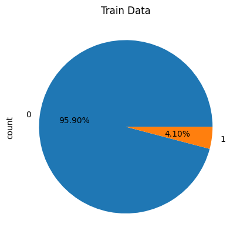

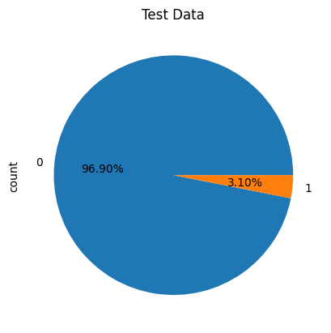

```python
y_train.value_counts().plot(kind = 'pie', autopct = "%1.2f%%", title= "Train Data")
plt.show()
y_test.value_counts().plot(kind = 'pie', autopct = "%1.2f%%", title="Test Data")
plt.show()
```

### OBSERVATIONS:

- Default rate is 4.10%, indicating Class Imbalance (where one class is underrepresented).

## Missing Values

```python
X_train.shape
```

```
(5556, 64)
```

```python
# MISSING DATA SUMMARY COLUMN WISE

# Find the total missing values in each row
def missing_data_summary_colwise(df):
    total = df.isnull().sum().sort_values(ascending=False)
    percent = df.isnull().mean() * 100
    percent = percent.sort_values(ascending=False)
    missing_data = pd.concat([total, percent], axis=1, keys=['Total', 'Percent'])
    return missing_data[missing_data["Total"]>0]

# Find the total missing values in each row
def missing_data_summary_rowwise(df):
    total = df.isnull().sum(axis=1)
    percent = (total / (df.shape[1])) * 100
    missing_data = pd.concat([total, percent], axis=1, keys=['Total', 'Percent'])
    missing_data = missing_data.sort_values(by='Total', ascending=False)
    return missing_data[missing_data["Total"]>0]

#to fetch the rows with given number of missing values
def get_missing_rows_by_total(total_value):
    t = missing_data_summary_colwise[missing_data_summary_colwise['Total'] == total_value]
    missing_rows = df[t.index][df[t.index].isnull().any(axis=1)]
    return missing_rows
```

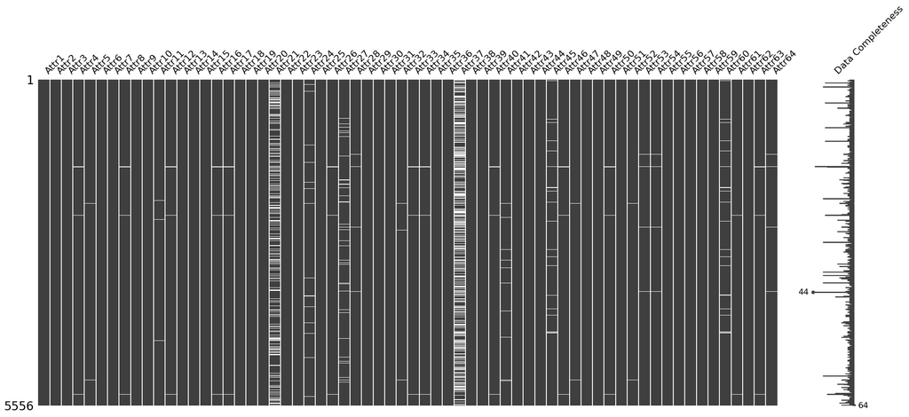

```python
msno.matrix(X_train, labels=True)
```

```python
#missing values column wise
missing_data_summary_colwise(X_train)
```

|  | Total | Percent |
| --- | --- | --- |
| Attr37 | 2155 | 38.786897 |
| Attr21 | 1308 | 23.542117 |
| Attr27 | 239 | 4.301656 |
| Attr60 | 106 | 1.907847 |
| Attr45 | 105 | 1.889849 |
| Attr24 | 101 | 1.817855 |
| Attr41 | 63 | 1.133909 |
| Attr11 | 34 | 0.611951 |
| Attr32 | 31 | 0.557955 |
| Attr53 | 23 | 0.413967 |
| Attr54 | 23 | 0.413967 |
| Attr28 | 23 | 0.413967 |
| Attr64 | 23 | 0.413967 |
| Attr52 | 22 | 0.395968 |
| Attr47 | 22 | 0.395968 |
| Attr46 | 22 | 0.395968 |
| Attr40 | 21 | 0.377970 |
| Attr63 | 21 | 0.377970 |
| Attr33 | 21 | 0.377970 |
| Attr12 | 21 | 0.377970 |
| Attr4 | 21 | 0.377970 |
| Attr16 | 16 | 0.287977 |
| Attr61 | 16 | 0.287977 |
| Attr50 | 16 | 0.287977 |
| Attr34 | 16 | 0.287977 |
| Attr26 | 16 | 0.287977 |
| Attr17 | 16 | 0.287977 |
| Attr8 | 16 | 0.287977 |
| Attr5 | 7 | 0.125990 |
| Attr10 | 1 | 0.017999 |
| Attr1 | 1 | 0.017999 |
| Attr9 | 1 | 0.017999 |
| Attr14 | 1 | 0.017999 |
| Attr48 | 1 | 0.017999 |
| Attr51 | 1 | 0.017999 |
| Attr38 | 1 | 0.017999 |
| Attr36 | 1 | 0.017999 |
| Attr6 | 1 | 0.017999 |
| Attr35 | 1 | 0.017999 |
| Attr2 | 1 | 0.017999 |
| Attr29 | 1 | 0.017999 |
| Attr25 | 1 | 0.017999 |
| Attr18 | 1 | 0.017999 |
| Attr3 | 1 | 0.017999 |
| Attr22 | 1 | 0.017999 |
| Attr7 | 1 | 0.017999 |

```python
print(missing_data_summary_colwise(X_train).shape)
```

```
(46, 2)
```

```python
#rows with missing values
missing_data_summary_rowwise(X_train)
```

|  | Total | Percent |
| --- | --- | --- |
| 5334 | 20 | 31.2500 |
| 279 | 19 | 29.6875 |
| 3908 | 15 | 23.4375 |
| 6293 | 15 | 23.4375 |
| 5986 | 15 | 23.4375 |
| 1232 | 15 | 23.4375 |
| 1814 | 15 | 23.4375 |
| 2499 | 15 | 23.4375 |
| 75 | 15 | 23.4375 |
| 6182 | 14 | 21.8750 |
| 644 | 14 | 21.8750 |
| 1715 | 14 | 21.8750 |
| 4422 | 14 | 21.8750 |
| 2434 | 14 | 21.8750 |
| 2259 | 13 | 20.3125 |
| 1677 | 13 | 20.3125 |
| 7005 | 9 | 14.0625 |
| 5600 | 9 | 14.0625 |
| 177 | 8 | 12.5000 |
| 6769 | 8 | 12.5000 |
| 82 | 8 | 12.5000 |
| 1411 | 8 | 12.5000 |
| 5283 | 8 | 12.5000 |
| 1919 | 7 | 10.9375 |
| 267 | 7 | 10.9375 |
| 5432 | 7 | 10.9375 |
| 238 | 7 | 10.9375 |
| 2679 | 7 | 10.9375 |
| 1417 | 6 | 9.3750 |
| 2887 | 6 | 9.3750 |

[output cut: 3006 more lines]

```python
t=X_train.loc[[279,3908,6293,5986,1232]]
t[t.isna()]
```

|  | Attr1 | Attr2 | Attr3 | Attr4 | Attr5 | Attr6 | Attr7 | Attr8 | Attr9 | Attr10 | Attr11 | Attr12 | Attr13 | Attr14 | Attr15 | Attr16 | Attr17 | Attr18 | Attr19 | Attr20 | Attr21 | Attr22 | Attr23 | Attr24 | Attr25 | Attr26 | Attr27 | Attr28 | Attr29 | … |
| --- | --- | --- | --- | --- | --- | --- | --- | --- | --- | --- | --- | --- | --- | --- | --- | --- | --- | --- | --- | --- | --- | --- | --- | --- | --- | --- | --- | --- | --- | --- |
| 279 | NaN | NaN | NaN | NaN | NaN | NaN | NaN | NaN | NaN | NaN | NaN | NaN | NaN | NaN | NaN | NaN | NaN | NaN | NaN | NaN | NaN | NaN | NaN | NaN | NaN | NaN | NaN | NaN | NaN | … |
| 3908 | NaN | NaN | NaN | NaN | NaN | NaN | NaN | NaN | NaN | NaN | NaN | NaN | NaN | NaN | NaN | NaN | NaN | NaN | NaN | NaN | NaN | NaN | NaN | NaN | NaN | NaN | NaN | NaN | NaN | … |
| 6293 | NaN | NaN | NaN | NaN | NaN | NaN | NaN | NaN | NaN | NaN | NaN | NaN | NaN | NaN | NaN | NaN | NaN | NaN | NaN | NaN | NaN | NaN | NaN | NaN | NaN | NaN | NaN | NaN | NaN | … |
| 5986 | NaN | NaN | NaN | NaN | NaN | NaN | NaN | NaN | NaN | NaN | NaN | NaN | NaN | NaN | NaN | NaN | NaN | NaN | NaN | NaN | NaN | NaN | NaN | NaN | NaN | NaN | NaN | NaN | NaN | … |
| 1232 | NaN | NaN | NaN | NaN | NaN | NaN | NaN | NaN | NaN | NaN | NaN | NaN | NaN | NaN | NaN | NaN | NaN | NaN | NaN | NaN | NaN | NaN | NaN | NaN | NaN | NaN | NaN | NaN | NaN | … |

The values in these rows are missing for the same attributes.

```python
missing_data_summary_colwise(X_train)[missing_data_summary_colwise(X_train)['Total']>0].shape
```

```
(46, 2)
```

```python
#shape
X_train.shape,X_test.shape, y_train.shape, y_test.shape
```

```
((5556, 64), (1389, 64), (5556,), (1389,))
```